# Children’s Emergency Department PodMonitor

[figure not shown]

[figure not shown]

(last event received: 2024-02-22 08:22:03.24)

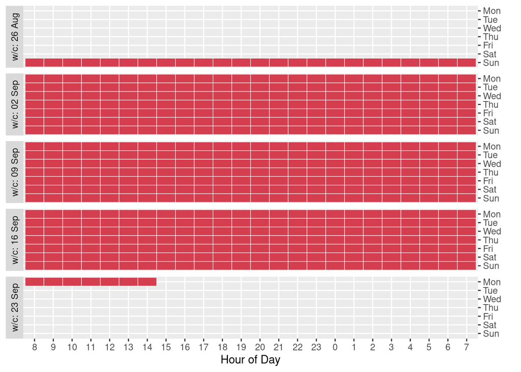

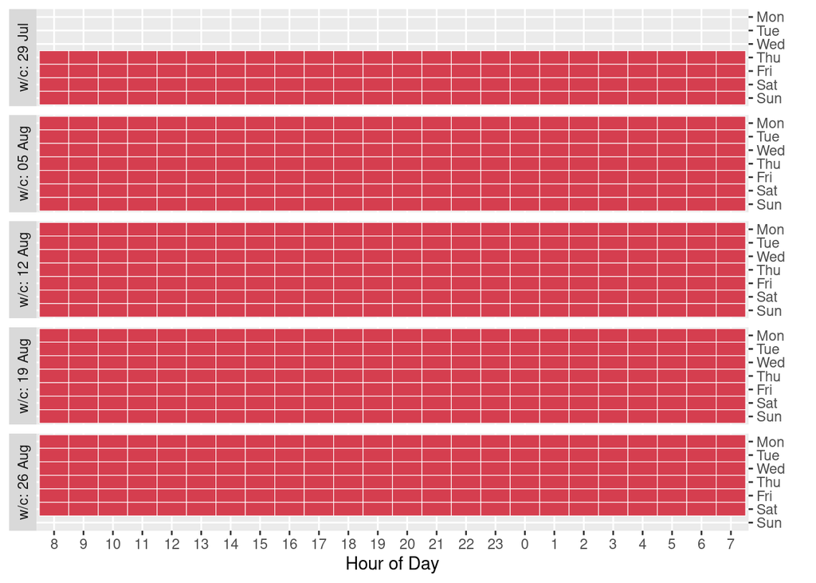

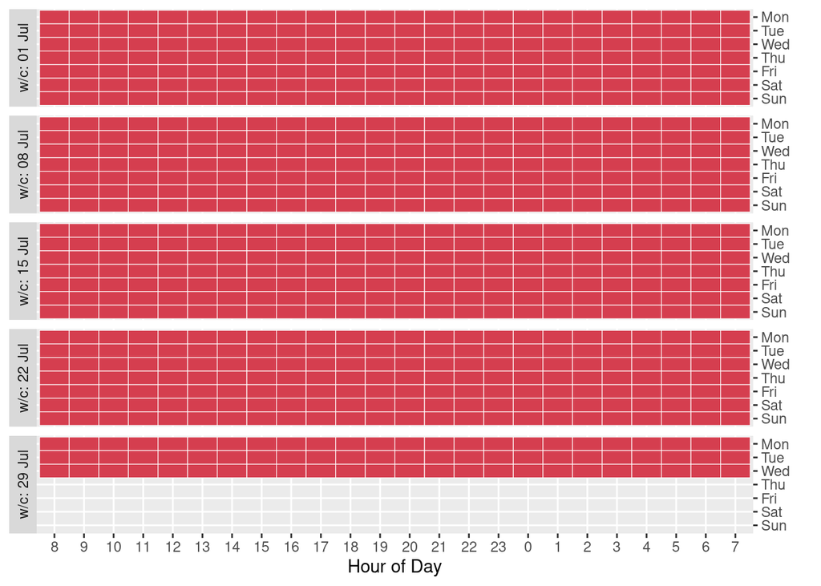

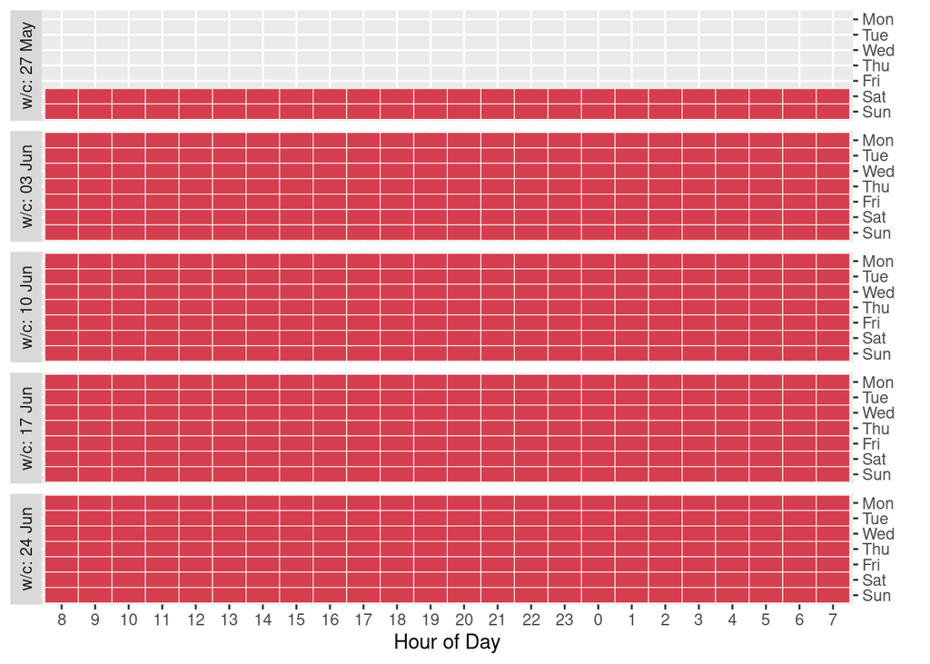

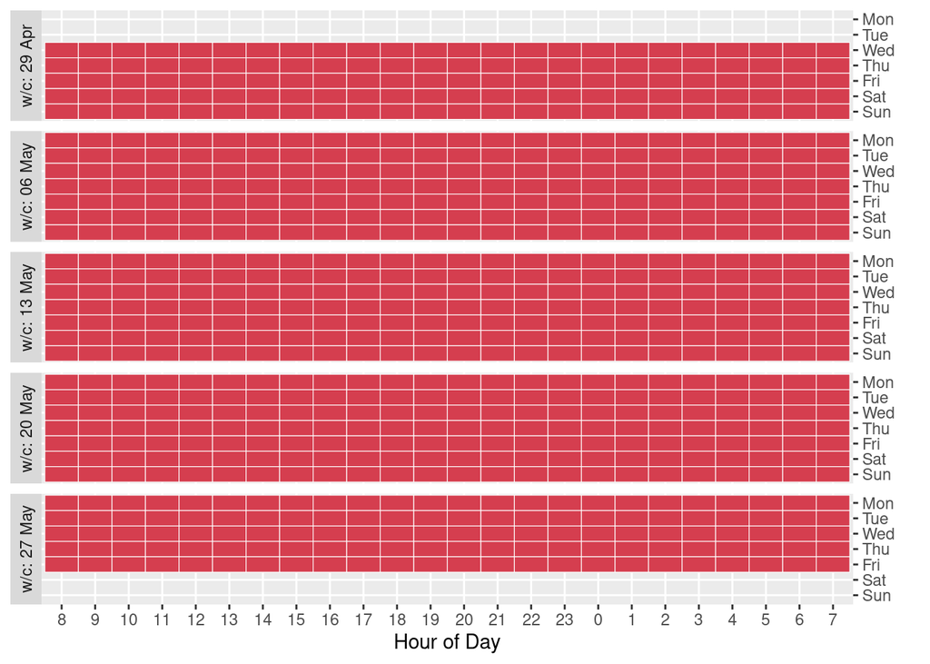

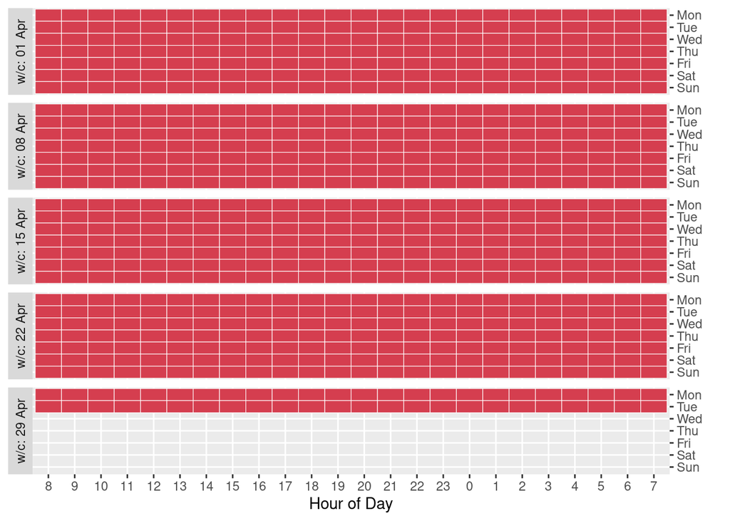

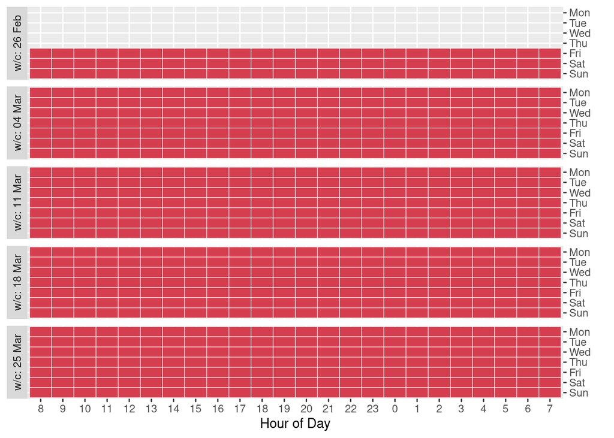

#### In February the pod was working 94.5% of the time.

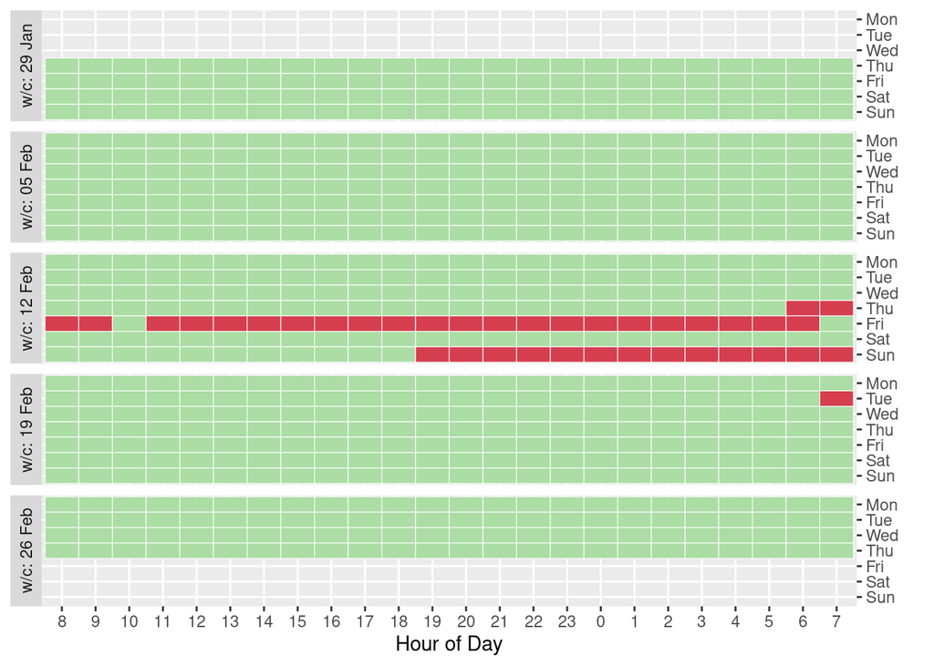

#### 116 pods were sent and 52 were not, equating to an additional 26 patient hours spent in CED.

#### In January the pod was working 79.6% of the time.

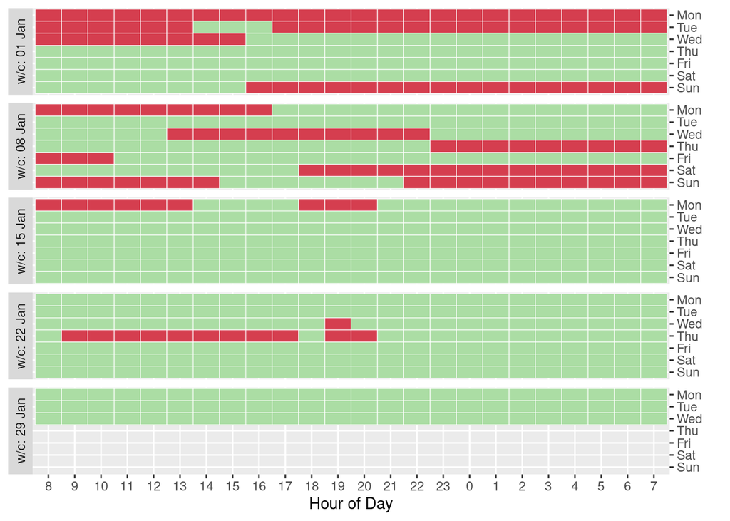

#### 88 pods were sent and 54 were not, equating to an additional 27 patient hours spent in CED.

#### In December the pod was working 34.8% of the time.

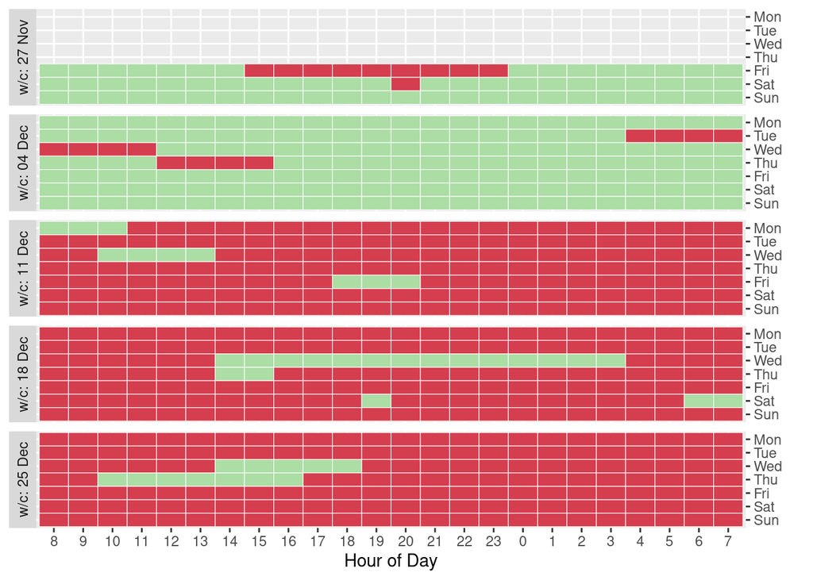

#### 99 pods were sent and 277 were not, equating to an additional 138.5 patient hours spent in CED.

#### In November the pod was working 61.8% of the time.

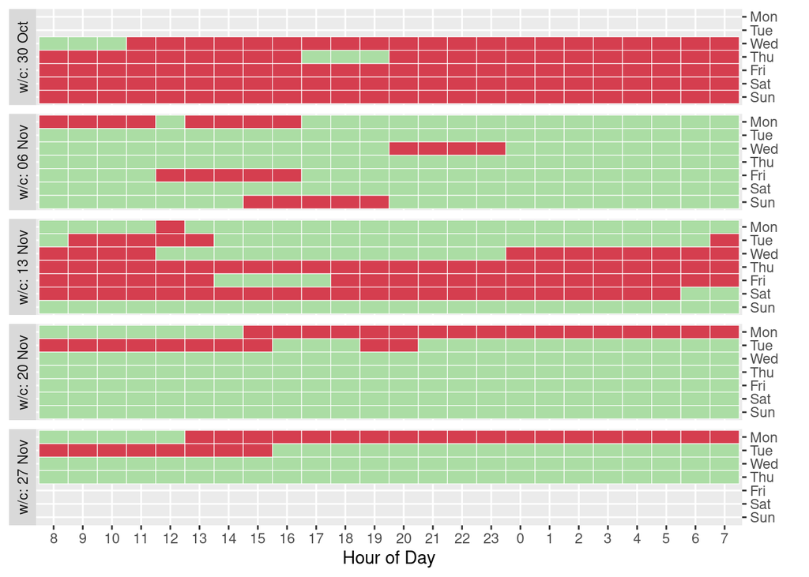

#### 174 pods were sent and 166 were not, equating to an additional 83 patient hours spent in CED.

#### In October the pod was working 50.5% of the time.

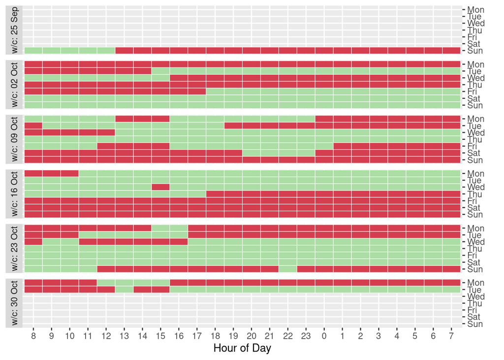

#### 204 pods were sent and 201 were not, equating to an additional 100.5 patient hours spent in CED.

#### So far in September the pod has worked 60.7% of the time.

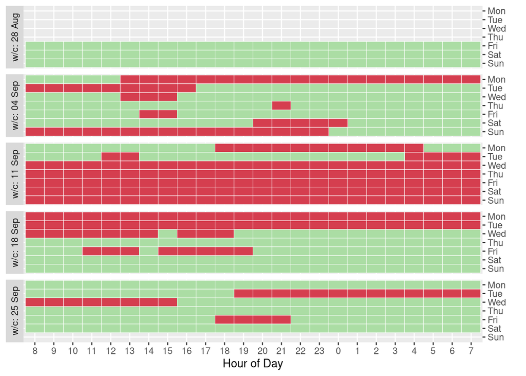

#### 276 pods have been sent and 270 have not, equating to an additional 135 patient hours spent in CED.

#### In August the pod was working 93.4% of the time.

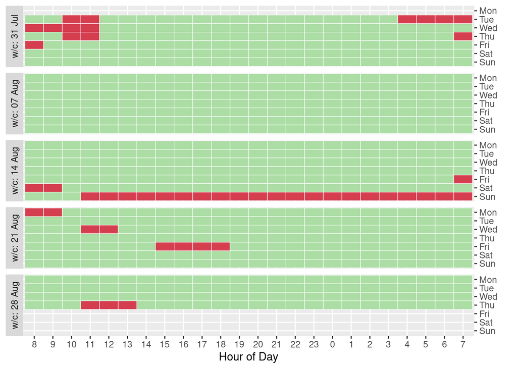

#### 377 pods were sent and 35 were not, equating to an additional 17.5 patient hours spent in CED.

#### In July the pod was working 42.7% of the time.

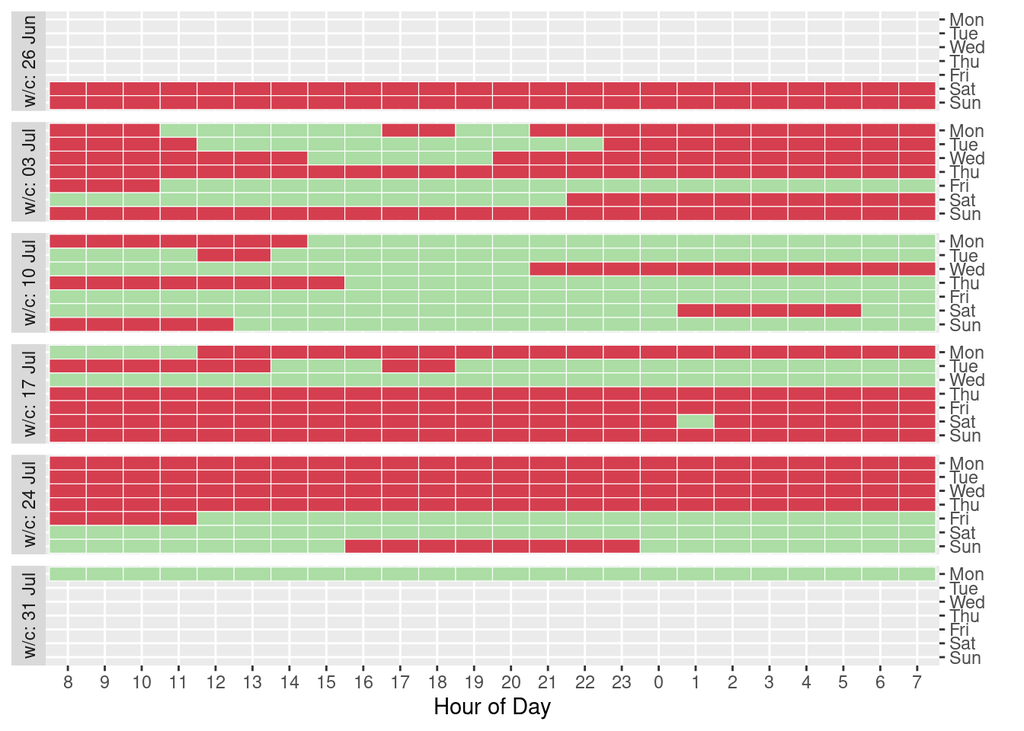

#### 258 pods were sent and 328 were not, equating to an additional 164 patient hours spent in CED.

#### In June the pod was working 64.5% of the time.

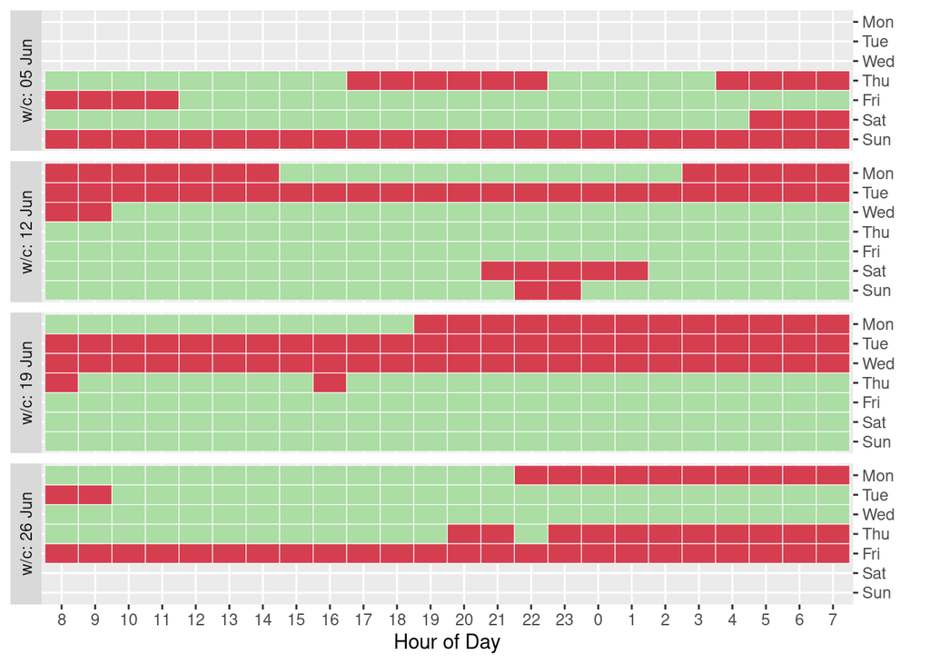

#### 328 pods were sent and 246 were not, equating to an additional 123 patient hours spent in CED.